# Procesamiento de datos masivos con R y RStudio

Yolanda García Ruiz - ygarciar@ucm.es

23/09/2025

# 1 Tablas de datos

Para referirnos a tablas de datos (estructura similar a una hoja de cálculo), usaremos el término dataframe. Se trata de una estructura **bidimensional** con sus filas y columnas.

- Cada columna representa una variable y tiene un tipo asociado. Cada columna del dataframe es, en realidad, otra estructura de datos, en concreto, un vector.

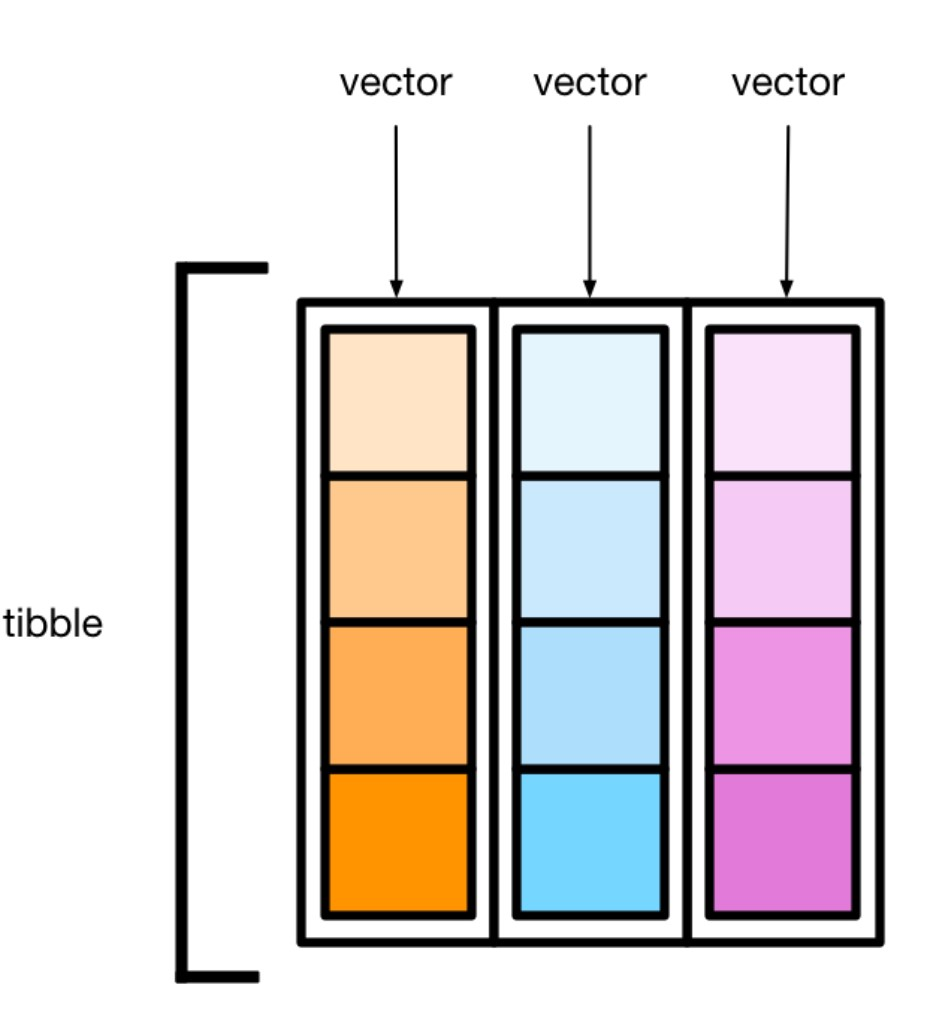

- Las columnas que forma un dataframe pueden tener distintos tipos.
- Cada fila del dataframe representa una observación.

En R encontramos dos tipos:

- data.frame
- tibbles

Los `tibbles` son las versiones modernas de los antiguos `data.frames`, pero modifican algunas características antiguas para hacernos la vida más fácil. En este curso usaremos tibbles.

La mayoría de las veces usaremos el término tibble y dataframe de manera indistinta; cuando queramos referirnos de manera particular al dataframe que viene incluido en R Base lo llamaremos `data.frame`.

## 1.1 Tablas de tipo `tibble`

La biblioteca `tibble` forma parte del ecosistema `tidyverse` y proporciona la estructura de datos `tibble`. Los `tibbles` están diseñados para ser más intuitivos y fáciles de usar que los `data.frames` tradicionales, proporcionando características adicionales y comportamientos más coherentes.

Además, la biblioteca `dplyr` proporciona un conjunto de operaciones para transformar los datos en dataframes de la forma más apropiada.

```r
library(tibble)
library(dplyr)
```

En el siguiente enlace podemos consultar la Cheat Sheet de las bibliotecas dplyr y tidyr.

### 1.1.1 Crear un dataframe

Un dataframe está compuesto por vectores, que representan cada una de las columnas. Los dataframes se pueden crear mediante la función `tibBle()`, indicando las columnas mediante vectores con nombre. Todos los vectores que proporcionemos deben tener el mismo tamaño.

```r
# Creación de las columnas de un tibble (dataframe)
edad <- c(20,45, 34)
altura <- c(1.56,1.72, 1.9)
sexo <- c('Male','Male', 'Female')

# Creación de un tibble (dataframe)
tb <-tibble(edad, altura, sexo)
tb
```

```
## # A tibble: 3 × 3
##    edad altura sexo
##   <dbl>  <dbl> <chr>
## 1    20   1.56 Male
## 2    45   1.72 Male
## 3    34   1.9  Female
```

Una vez creado el dataframe, podemos visualizarlo desde la pestaña `Environment` de RStudio.

### 1.1.2 Creación de dataframe a partir de ficheros

Lo más habitual cuando se trabaja con datos, no es crear dataframes de forma manual, sino crearlos mediante la lectura de ficheros. La biblioteca `readr` forma parte del ecosistema del `tidyverse` y contiene funciones para la lectura eficiente de archivos de datos delimitados, como archivos CSV, TSV y otros formatos similares.

El siguiente bloque de código crea un dataframe (de tipo tibble) a partir de un fichero usando la función `read_csv()`.

```r
# carga de la librería
library(readr)
```

```r
# Creación de un dataframe a partir de un fichero de datos
filmin <- read_csv("../data/filmin.csv", n_max = 80)
filmin
```

```
## # A tibble: 80 × 4
##    Titulo                     Anio Valoracion Genero
##    <chr>                     <dbl>      <dbl> <chr>
##  1 Sin Rodeos                   NA        7.5 Comedia
##  2 Perdido                    2017       NA   Drama
##  3 El viaje de sus vidas      2017        7   Romántica
##  4 Historias de una indecisa    NA       NA   Comedia
##  5 Solo el Fin del Mundo        NA       NA   Drama
##  6 Olvídate de Nick           2017        6.2 Comedia
##  7 Atracadores                2015        7   Acción
##  8 Disorder: El Protector     2015        7   Thriller
##  9 Verano en Brooklyn         2016       NA   Drama
## 10 El Joven Kieslowski        2014        7.1 Romántica
## # ℹ 70 more rows
```

Como se puede observar, solo se muestra las primeras filas y todas las columnas que caben en la pantalla. Desde el `Environment` de RStudio se puede hacer click sobre el dataframe para ver todas las columnas.

Debajo de cada variable (columna) aparecen los tipos de datos de dicha variable.

### 1.1.3 Características generales de dataframes

```r
# Dimensión de un dataframe
dim(filmin)
```

```
## [1] 80  4
```

```r
# Número de columnas
length(filmin)
```

```
## [1] 4
```

```r
ncol(filmin)
```

```
## [1] 4
```

```r
# Número de filas
nrow(filmin)
```

```
## [1] 80
```

```r
# Nombres de las columnas
names(filmin)         # colnames también funciona
```

```
## [1] "Titulo"     "Anio"       "Valoracion" "Genero"
```

Para **visualizar el dataframe:**

```r
View(filmin)
```

Para **calcular los primeros estadísticos:**

```r
# primeros estadísticos
summary(filmin)
```

```
##     Titulo               Anio        Valoracion     Genero
##  Length:80          Min.   :1971   Min.   :5.9   Length:80
##  Class :character   1st Qu.:2016   1st Qu.:7.0   Class :character
##  Mode  :character   Median :2017   Median :7.2   Mode  :character
##                     Mean   :2016   Mean   :7.3
##                     3rd Qu.:2017   3rd Qu.:7.8
##                     Max.   :2018   Max.   :9.0
##                     NA's   :5      NA's   :5
```

No nos olvidemos que las columnas de un dataframe son vectores, por lo que podremos usar las operaciones de vectores para cada una de las columnas.

El acceso a los valores de una columna se realiza mediante `$` y el resultado es un vector.

```r
filmin$Genero
```

```
##  [1] "Comedia"            "Drama"              "Romántica"
##  [4] "Comedia"            "Drama"              "Comedia"
##  [7] "Acción"             "Thriller"           "Drama"
## [10] "Romántica"          "Comedia"            "Drama"
## [13] "Drama"              "Drama"              "Comedia"
## [16] "Comedia"            "Biopic"             "Thriller"
## [19] "Comedia"            "Comedia"            "Comedia"
## [22] "Drama"              "Documental"         "Documental"
## [25] "Documental"         "Romántica"          "Drama"
## [28] "Acción"             "Drama"              "Drama"
## [31] "Documental"         "Documental"         "Thriller"
## [34] "Drama"              "Drama"              "Documental"
## [37] "Thriller"           "Documental"         "Drama"
## [40] "Comedia"            "Drama"              "Drama"
## [43] "Terror"             "Thriller"           "Drama"
## [46] "Thriller"           "Drama"              "Comedia"
## [49] "Drama"              "Drama"              "Aventuras"
## [52] "Drama"              "Romántica"          "Documental"
## [55] "Drama"              "Drama"              "Drama"
## [58] "Thriller"           "Thriller"           "Comedia"
## [61] "Aventuras"          "Aventuras"          "Comedia"
## [64] "Thriller"           "Comedia"            "Drama"
## [67] "Drama"              "Comedia"            "Drama"
## [70] "Comedia"            "Drama"              "Drama"
## [73] "Drama"              "Documental musical" "Thriller"
## [76] "Comedia"            "Documental"         "Romántica"
## [79] "Cine clásico"       "Thriller"
```

Podremos preguntar por la frecuencia de cada valor en una columna o los distintos valores existentes en una columna.

```r
# frecuencia
table(filmin$Genero)
```

```
##
##             Acción          Aventuras             Biopic       Cine clásico
##                  2                  3                  1                  1
##            Comedia         Documental Documental musical              Drama
##                 17                  9                  1                 29
##          Romántica             Terror           Thriller
##                  5                  1                 11
```

```r
# distintos valores existentes en la columna genero
unique(filmin$Genero)
```

```
##  [1] "Comedia"            "Drama"              "Romántica"
##  [4] "Acción"             "Thriller"           "Biopic"
##  [7] "Documental"         "Terror"             "Aventuras"
## [10] "Documental musical" "Cine clásico"
```

```r
# cuántos géneros distintos hay
length(unique(filmin$Genero))
```

```
## [1] 11
```

## 1.2 Transformación de datos con la biblioteca `dplyr`

`dplyr` es una biblioteca que se enfoca en la manipulación de datos. Dentro del paquete `dplyr` se dispone de una serie de “verbos” (funciones) para una sola tabla, que se pueden agrupar en tres categorías:

- para trabajar con filas,
- para trabajar con columnas
- para resumir datos.

Todas las funciones definidas en `dplyr` funcionan de manera similar.

- El primer argumento es un dataframe
- El resto de parámetros describe lo que debe hacer la función (columnas sin comillas)
- El resultado es un dataframe

### 1.2.1 Operaciones con filas

Los verbos definidos para estas operaciones son:

#### 1.2.1.1 `filter()` para el acceso a filas

Cuando trabajamos con tibbles, no se suele usar el operador `[ ]` para realizar la selección de filas.

El filtrado de datos consiste en seleccionar las observaciones o filas de acuerdo a sus valores.

**Ejemplo**: Por ejemplo, para seleccionar las películas del género ‘Drama’, escribimos lo siguiente:

```r
filter(filmin, Genero == 'Drama')
```

```
## # A tibble: 29 × 4
##    Titulo                 Anio Valoracion Genero
##    <chr>                 <dbl>      <dbl> <chr>
##  1 Perdido                2017       NA   Drama
##  2 Solo el Fin del Mundo    NA       NA   Drama
##  3 Verano en Brooklyn     2016       NA   Drama
##  4 María (y los demás)      NA        7   Drama
##  5 Yo, Daniel Blake       2016        8.4 Drama
##  6 On the Road              NA        7.2 Drama
##  7 Blue my Mind           2017        7.2 Drama
##  8 Cartas de Berlín       2016        7.4 Drama
##  9 En la sombra           2017        8   Drama
## 10 Foxtrot                2017        7.1 Drama
## # ℹ 19 more rows
```

El resultado es un dataframe con 29 filas y 4 columnas.

Se pueden realizar múltiples filtrados de acuerdo a determinados requisitos. Los requisitos se expresan utilizando operaciones lógicas:

- Comparación: <=, <, ==, >, >=, !=
- Conjunción `&` (operador and). El operador & se puede sustituir por la coma (,). Se pueden anidar tantas condiciones como se desee.
- Disyunción `|` (operador or).
- Pertenencia: `%in%` para comprobar si un dato está en un conjunto de valores.

**Ejemplo**: Por ejemplo, para seleccionar las filas que se corresponden con películas del género ‘Drama’ con valoración mayor de 6, podemos escribir:

```r
filter(filmin, (Genero == 'Drama') & (Valoracion > 6))
```

```
## # A tibble: 26 × 4
##    Titulo                Anio Valoracion Genero
##    <chr>                <dbl>      <dbl> <chr>
##  1 María (y los demás)     NA        7   Drama
##  2 Yo, Daniel Blake      2016        8.4 Drama
##  3 On the Road             NA        7.2 Drama
##  4 Blue my Mind          2017        7.2 Drama
##  5 Cartas de Berlín      2016        7.4 Drama
##  6 En la sombra          2017        8   Drama
##  7 Foxtrot               2017        7.1 Drama
##  8 Después de la guerra  2017        7.8 Drama
##  9 Atrapa el viento      2017        7.8 Drama
## 10 Sin Amor              2016        7   Drama
## # ℹ 16 more rows
```

**Ejemplo:** Si buscamos los películas de los géneros ‘Romántica’ y ‘Comedia’, podemos escribir:

```r
df <-filter(filmin, Genero %in% c('Romántica' , 'Comedia'))
df
```

```
## # A tibble: 22 × 4
##    Titulo                     Anio Valoracion Genero
##    <chr>                     <dbl>      <dbl> <chr>
##  1 Sin Rodeos                   NA        7.5 Comedia
##  2 El viaje de sus vidas      2017        7   Romántica
##  3 Historias de una indecisa    NA       NA   Comedia
##  4 Olvídate de Nick           2017        6.2 Comedia
##  5 El Joven Kieslowski        2014        7.1 Romántica
##  6 Ni jueza, ni sumisa        2017        7.5 Comedia
##  7 Sing Street                2016       NA   Comedia
##  8 Footnotes                  2017        7.1 Comedia
##  9 La Tribu                   2018        6.2 Comedia
## 10 La muerte de Stalin        2017        6.8 Comedia
## # ℹ 12 more rows
```

El resultado es un nuevo dataframe que se puede asignar a una nueva variable usando la asignación `<-`.

Los operadores que se puede usar son:

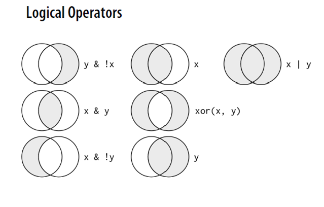

#### 1.2.1.2 `slice()` para extraer filas por su índice

Se trata de una familia de funciones que extraen filas de un dataframe por su índice. Veamos algunos ejemplos:

**Ejemplo:** muestra las 2 primeras filas

```r
# mostrar un número determinado de filas
slice_head(filmin, n=2)  # muestra las 2 primeras filas
```

```
## # A tibble: 2 × 4
##   Titulo      Anio Valoracion Genero
##   <chr>      <dbl>      <dbl> <chr>
## 1 Sin Rodeos    NA        7.5 Comedia
## 2 Perdido     2017       NA   Drama
```

**Ejemplo:** muestra el 50% de las últimas filas

```r
# muestra el 50% de las ultimas filas
slice_tail(filmin, prop=0.5)
```

```
## # A tibble: 40 × 4
##    Titulo                      Anio Valoracion Genero
##    <chr>                      <dbl>      <dbl> <chr>
##  1 Cuando tienes 17 años       2016        7   Drama
##  2 La Juventud                 2015        8.1 Drama
##  3 The Neon Demon              2016        6.4 Terror
##  4 London Road                 2015        7.2 Thriller
##  5 Los asesinos de Snowtown    2011        7.3 Drama
##  6 La hora de la venganza      2017        6.4 Thriller
##  7 El sentido de un final      2017        7.8 Drama
##  8 The Party                   2017        7   Comedia
##  9 Los archivos del Pentágono  2017        7.4 Drama
## 10 The Florida Project         2017        8   Drama
## # ℹ 30 more rows
```

**Ejemplo:** muestra 3 filas aleatorias

```r
# obtiene una muestra aleatoria de n filas (o proporción prop)
set.seed(1)  # Para que la muestra aleatoria sea reproducible
slice_sample(filmin, n = 3)
```

```
## # A tibble: 3 × 4
##   Titulo       Anio Valoracion Genero
##   <chr>       <dbl>      <dbl> <chr>
## 1 Saint Amour  2016        6.9 Comedia
## 2 Sin Amor     2016        7   Drama
## 3 Sin Rodeos     NA        7.5 Comedia
```

**Ejemplo:** muestra las filas con el mínimo valor en una variable

```r
# obtienen las filas que contienen los menores valores  de la
# variable indicada en el argumento order_by
slice_min(filmin, order_by = Valoracion)
```

```
## # A tibble: 1 × 4
##   Titulo              Anio Valoracion Genero
##   <chr>              <dbl>      <dbl> <chr>
## 1 Terapia Padre-Hijo  2015        5.9 Comedia
```

#### 1.2.1.3 `arrange()` para ordenar las filas por algún criterio

La función `arrange` permite ordenar los datos en base a los valores de las columnas.

```r
# Ordenar ascendente de 'número' y luego descendente de  'sexo'
df_ordenado <- arrange(filmin,  Anio, desc(Valoracion))
print(df_ordenado)
```

```
## # A tibble: 80 × 4
##    Titulo                      Anio Valoracion Genero
##    <chr>                      <dbl>      <dbl> <chr>
##  1 Punishment Park             1971        8.7 Cine clásico
##  2 Sexy Beast                  2000        7.8 Thriller
##  3 Los asesinos de Snowtown    2011        7.3 Drama
##  4 El Joven Kieslowski         2014        7.1 Romántica
##  5 La Juventud                 2015        8.1 Drama
##  6 La Estación de las Mujeres  2015        7.8 Comedia
##  7 London Road                 2015        7.2 Thriller
##  8 Atracadores                 2015        7   Acción
##  9 Disorder: El Protector      2015        7   Thriller
## 10 El paraíso perdido          2015        7   Drama
## # ℹ 70 more rows
```

Para ordenar alguna de las variables de forma descendente, usamos `desc()`:

```r
# Ordenar descendente de 'número' y luego ascendente de 'Genero'
df_ordenado <- arrange(filmin,  desc(Anio), Genero)
print(df_ordenado)
```

```
## # A tibble: 80 × 4
##    Titulo                          Anio Valoracion Genero
##    <chr>                          <dbl>      <dbl> <chr>
##  1 Gringo: Se busca vivo o muerto  2018        7.4 Acción
##  2 Samantha Hudson                 2018        8   Biopic
##  3 La Tribu                        2018        6.2 Comedia
##  4 Cavernícola                     2018        7.1 Comedia
##  5 Amateurs                        2018        7.8 Comedia
##  6 Out                             2018        8   Documental
##  7 El caso Kurt Waldheim           2018        9   Documental
##  8 Permanent Green Light           2018        8.2 Drama
##  9 Tower. A bright day             2018        7.1 Drama
## 10 Desaparecer                     2018        7.1 Drama
## # ℹ 70 more rows
```

### 1.2.2 Operaciones con columnas

Los verbos definidos para estas operaciones son:

#### 1.2.2.1 `select()` para indicar cuando una columna se incluye o no

Para seleccionar columnas usamos la función `select()`. El primer argumento es un dataframe y el resto son las columnas a seleccionar.

Por ejemplo, si queremos seleccionar las columnas 2 y 1, escribiremos:

```r
a <- select(filmin, 2, 1)
slice_tail(a, n = 7)
```

```
## # A tibble: 7 × 2
##    Anio Titulo
##   <dbl> <chr>
## 1  2017 Luz de Agosto en Gijón
## 2  2017 El orden de las cosas
## 3  2018 Amateurs
## 4  2017 Una oportunidad para ellos
## 5  2018 Puta y amada
## 6  1971 Punishment Park
## 7  2000 Sexy Beast
```

También podemos seleccionar columnas por nombre:

```r
colnames(filmin)
```

```
## [1] "Titulo"     "Anio"       "Valoracion" "Genero"
```

```r
a <- select(filmin, "Valoracion", "Genero")
slice_head(a, n = 5)
```

```
## # A tibble: 5 × 2
##   Valoracion Genero
##        <dbl> <chr>
## 1        7.5 Comedia
## 2       NA   Drama
## 3        7   Romántica
## 4       NA   Comedia
## 5       NA   Drama
```

Seleccionar un rango de columnas mediante la notación `inicio:fin`. Para seleccionar el rango de las columnas entre la 2 y 4 (ambas inclusive) escribimos:

```r
a <- select(filmin, 2:4)
slice_tail(a, n = 5)
```

```
## # A tibble: 5 × 3
##    Anio Valoracion Genero
##   <dbl>      <dbl> <chr>
## 1  2018        7.8 Comedia
## 2  2017        7.2 Documental
## 3  2018        6.3 Romántica
## 4  1971        8.7 Cine clásico
## 5  2000        7.8 Thriller
```

Por ejemplo, para seleccionar las tres últimas columnas escribimos:

```r
inicio <-length(filmin)-2
fin <- length(filmin)
a <- select(filmin, inicio:fin)
slice_tail(a, n = 5)
```

```
## # A tibble: 5 × 3
##    Anio Valoracion Genero
##   <dbl>      <dbl> <chr>
## 1  2018        7.8 Comedia
## 2  2017        7.2 Documental
## 3  2018        6.3 Romántica
## 4  1971        8.7 Cine clásico
## 5  2000        7.8 Thriller
```

Para seleccionar todas las columnas excepto las tres últimas, usamos el signo negativo (`-`):

```r
a <- select(filmin, -(inicio:fin))
slice_tail(a, n = 5)
```

```
## # A tibble: 5 × 1
##   Titulo
##   <chr>
## 1 Amateurs
## 2 Una oportunidad para ellos
## 3 Puta y amada
## 4 Punishment Park
## 5 Sexy Beast
```

Hay una serie de funciones auxiliares que puedes usar dentro de `select()`.

- `starts_with("abc")`: coincide con los nombres que comienzan con “abc”.

  ```r
  a <- select(filmin, starts_with("Ge"))
  tail(a)
  ```

  ```
  ## # A tibble: 6 × 1
  ##   Genero
  ##   <chr>
  ## 1 Thriller
  ## 2 Comedia
  ## 3 Documental
  ## 4 Romántica
  ## 5 Cine clásico
  ## 6 Thriller
  ```

- `ends_with("xyz")`: coincide con los nombres que terminan con “xyz”.

  ```r
  a <- select(filmin, ends_with("o"))
  slice_tail(a, n = 5)
  ```

  ```
  ## # A tibble: 5 × 3
  ##   Titulo                      Anio Genero
  ##   <chr>                      <dbl> <chr>
  ## 1 Amateurs                    2018 Comedia
  ## 2 Una oportunidad para ellos  2017 Documental
  ## 3 Puta y amada                2018 Romántica
  ## 4 Punishment Park             1971 Cine clásico
  ## 5 Sexy Beast                  2000 Thriller
  ```

`contains("ijk")`: coincide con los nombres que contienen “ijk”.

```r
a <- select(filmin, contains("a") & ends_with("o"))
slice_tail(a, n = 5)
```

```
## # A tibble: 5 × 1
##    Anio
##   <dbl>
## 1  2018
## 2  2017
## 3  2018
## 4  1971
## 5  2000
```

#### 1.2.2.2 `mutate()` cambia los valores de las columnas y crea nuevas columnas

La función `mutate()` permite crear nuevas columnas en función de columnas existentes. También podemos usar `mutate()` para eliminar columnas o modificar los valores de columnas.

```r
library(stringr)      # para trabajar con strings

filmin <- mutate(filmin,
        redondeo = round(Valoracion),  # nueva
        escala5 = Valoracion / 2,      # nueva
        Year  = as.character(Anio),    # modificamos el tipo de columna fecha
        YY = str_sub(Year, 3, 4),      # nueva
        Anio = NULL)                   # BORRADO DE COLUMNA
```

```r
slice_head(filmin, n = 10)
```

```
## # A tibble: 10 × 7
##    Titulo                    Valoracion Genero    redondeo escala5 Year  YY
##    <chr>                          <dbl> <chr>        <dbl>   <dbl> <chr> <chr>
##  1 Sin Rodeos                       7.5 Comedia          8    3.75 <NA>  <NA>
##  2 Perdido                         NA   Drama           NA   NA    2017  17
##  3 El viaje de sus vidas            7   Romántica        7    3.5  2017  17
##  4 Historias de una indecisa       NA   Comedia         NA   NA    <NA>  <NA>
##  5 Solo el Fin del Mundo           NA   Drama           NA   NA    <NA>  <NA>
##  6 Olvídate de Nick                 6.2 Comedia          6    3.1  2017  17
##  7 Atracadores                      7   Acción           7    3.5  2015  15
##  8 Disorder: El Protector           7   Thriller         7    3.5  2015  15
##  9 Verano en Brooklyn              NA   Drama           NA   NA    2016  16
## 10 El Joven Kieslowski              7.1 Romántica        7    3.55 2014  14
```

**Alguna de las funciones útiles para la creación o modificación de columnas:**

- Operadores aritméticos: `+`, `-`,`*`,`/`,`^`. Todos ellos funcionan bien con vectores (las columnas son vectores) puesto que son operaciones vectorizadas.
- Operadores de aritmética modular: %% y %/%
- Logaritmos: `log()`, `log2()`, `log10()`
- Rezagos: `lead()` y `lag()` para referirnos al valor por detrás o por delante
- Agregados acumulativos y móviles: `cumsum()`, `cumprod()`, `cummin()`, `cummax()`, `cummean()`

#### 1.2.2.3 `rename()` cambia el nombre de la columna.

La función `rename()` se utiliza para cambiar el nombre de las variables o columnas del dataframe. Por ejemplo, para renombrar la columna ‘redondeo’ por ‘Round’, escribimos:

```r
filmin <- rename(filmin, 'Round' = redondeo)
select(filmin, 5:6)
```

```
## # A tibble: 80 × 2
##    escala5 Year
##      <dbl> <chr>
##  1    3.75 <NA>
##  2   NA    2017
##  3    3.5  2017
##  4   NA    <NA>
##  5   NA    <NA>
##  6    3.1  2017
##  7    3.5  2015
##  8    3.5  2015
##  9   NA    2016
## 10    3.55 2014
## # ℹ 70 more rows
```

Para renombrar un conjunto de columnas, podemos hacerlo mediante un vector y la función `all_of()`.

```r
nuevos_nombres <- c(Title = 'Titulo',
                    Rate = 'Valoracion',
                    Genre = 'Genero')

filmin_2 <- rename(filmin, all_of(nuevos_nombres))
slice_head(filmin_2, n=5)
```

```
## # A tibble: 5 × 7
##   Title                      Rate Genre     Round escala5 Year  YY
##   <chr>                     <dbl> <chr>     <dbl>   <dbl> <chr> <chr>
## 1 Sin Rodeos                  7.5 Comedia       8    3.75 <NA>  <NA>
## 2 Perdido                    NA   Drama        NA   NA    2017  17
## 3 El viaje de sus vidas       7   Romántica     7    3.5  2017  17
## 4 Historias de una indecisa  NA   Comedia      NA   NA    <NA>  <NA>
## 5 Solo el Fin del Mundo      NA   Drama        NA   NA    <NA>  <NA>
```

### 1.2.3 Operaciones de resumen y agrupación

#### 1.2.3.1 `glimpse()` para un resumen de la estructura de un dataframe.

```r
glimpse(filmin)
```

```
## Rows: 80
## Columns: 7
## $ Titulo     <chr> "Sin Rodeos", "Perdido", "El viaje de sus vidas", "Historia…
## $ Valoracion <dbl> 7.5, NA, 7.0, NA, NA, 6.2, 7.0, 7.0, NA, 7.1, 7.5, 7.0, 8.4…
## $ Genero     <chr> "Comedia", "Drama", "Romántica", "Comedia", "Drama", "Comed…
## $ Round      <dbl> 8, NA, 7, NA, NA, 6, 7, 7, NA, 7, 8, 7, 8, 7, NA, 7, 8, 8, …
## $ escala5    <dbl> 3.75, NA, 3.50, NA, NA, 3.10, 3.50, 3.50, NA, 3.55, 3.75, 3…
## $ Year       <chr> NA, "2017", "2017", NA, NA, "2017", "2015", "2015", "2016",…
## $ YY         <chr> NA, "17", "17", NA, NA, "17", "15", "15", "16", "14", "17",…
```

#### 1.2.3.2 `summarise()` (o su alias `summarize()`) y `group_by()`

La función `summarise` (o su alias `summarize`) se utiliza para crear resúmenes de variables en un dataframe.

Por ejemplo, si queremos calcular el número de años distintos (`n_distinct()`), el número de filas (`n()`) y la media de valoraciones de las películas, escribimos:

```r
summarise(filmin,
          count_years = n_distinct(Year),   # Número de años distintos
          total = n(), # número de filas
          media = mean(Valoracion, na.rm = TRUE),# media de las valoraciones
          min_val = min(Valoracion, na.rm = TRUE),
          max_val = max(Valoracion))
```

```
## # A tibble: 1 × 5
##   count_years total media min_val max_val
##         <int> <int> <dbl>   <dbl>   <dbl>
## 1           9    80   7.3     5.9      NA
```

El resultado es un nuevo dataframe con una única fila.

Esta función es especialmente útil cuando se combina con `group_by` para calcular estadísticas agregadas para diferentes grupos dentro del dataframe.

Si quisiéramos calcular el total de películas por género, tendríamos que usar la función `group_by()` para agrupar por género y posteriormente `summarise()` para cada uno de los grupos.

```r
# Agrupamos los datos por género
grupos <- group_by(filmin, Genero)
# Calculamos la media de la valoración
summarise(grupos,
          media = mean(Valoracion, na.rm =T))
```

```
## # A tibble: 11 × 2
##    Genero             media
##    <chr>              <dbl>
##  1 Acción              7.2
##  2 Aventuras           6.5
##  3 Biopic              8
##  4 Cine clásico        8.7
##  5 Comedia             7.04
##  6 Documental          7.68
##  7 Documental musical  7.3
##  8 Drama               7.40
##  9 Romántica           7.34
## 10 Terror              6.4
## 11 Thriller            7.23
```

Más adelante hablaremos de la función `pipe (%>%)`, pero la introducimos aquí para ejemplarizar su uso. La instrucción anterior se puede simplificar escribiendo:

```r
resultado <- filmin %>%
             group_by(Genero) %>%
             summarise(media = mean(Valoracion, na.rm =T))
resultado
```

```
## # A tibble: 11 × 2
##    Genero             media
##    <chr>              <dbl>
##  1 Acción              7.2
##  2 Aventuras           6.5
##  3 Biopic              8
##  4 Cine clásico        8.7
##  5 Comedia             7.04
##  6 Documental          7.68
##  7 Documental musical  7.3
##  8 Drama               7.40
##  9 Romántica           7.34
## 10 Terror              6.4
## 11 Thriller            7.23
```

Si quisiéramos calcular el número de valoraciones por Anio y Genero, escribimos lo siguiente:

```r
colnames(filmin)
```

```
## [1] "Titulo"     "Valoracion" "Genero"     "Round"      "escala5"
## [6] "Year"       "YY"
```

```r
grupos <- group_by(filmin, Year, Genero)
res <-summarise(grupos,
            numero_registros = n(),    # cuenta
            q25 = quantile(Valoracion, 0.25, na.rm = T),
            .groups = 'drop')
res
```

```
## # A tibble: 31 × 4
##    Year  Genero       numero_registros   q25
##    <chr> <chr>                   <int> <dbl>
##  1 1971  Cine clásico                1  8.7
##  2 2000  Thriller                    1  7.8
##  3 2011  Drama                       1  7.3
##  4 2014  Romántica                   1  7.1
##  5 2015  Acción                      1  7
##  6 2015  Aventuras                   1  6.4
##  7 2015  Comedia                     3  6.45
##  8 2015  Drama                       2  7.28
##  9 2015  Thriller                    2  7.05
## 10 2016  Aventuras                   1  6
## # ℹ 21 more rows
```

`.groups = "drop"` Elimina todos los grupos después de aplicar la función `summarize()`, dejando un dataframe sin agrupar.

**Operaciones de agregación más comunes:**

- Medidas de centralidad: hemos usado `mean(x)`, pero `median(x)`
- Medidas de dispersión: desviación estándar `sd(x)` , el rango intercuartílico `IQR()` y la desviación media absoluta `mad(x)`
- Medidas de rango: `min(x)`, `quantile(x, 0.25)`, `max(x)`.
- Medidas de posición: `first(x)`, `nth(x, 2)`, `last(x)`
- Conteos: `n()`, que no toma argumentos y que devuelve el tamaño del grupo actual. Para contar la cantidad de valores no faltantes, usa `sum(!is.na (x))`. Para contar la cantidad de valores distintos (únicos), usa `n_distinct(x)`.

## 1.3 El operador `pipe` para combinar múltiples operaciones

En R, el operador pipe `%>%` del paquete `dplyr` permite encadenar múltiples operaciones. Este enfoque es especialmente útil para realizar una serie de transformaciones en un dataframe de manera secuencial.

Supongamos que queremos realizar las siguientes operaciones sobre el dataframe `filmin`:

1. Seleccionar las columnas Year, Genero y Valoración
2. Filtrar las filas del año 2017 y 2015
3. Calcular el número de registros y la valoración media por Año y género:

Las operaciones serían:

```r
t1 <- select(filmin, -Titulo)
t2 <- filter(t1, Year %in% c(2017, 2015) )
t3 <- group_by(t2, Periodo = Year, Categoria = Genero )
t4 <- summarise(t3, total = sum(Valoracion, na.rm =T),
                    media = mean(Valoracion, na.rm =T),
                .groups = 'drop')

t4
```

```
## # A tibble: 12 × 4
##    Periodo Categoria          total media
##    <chr>   <chr>              <dbl> <dbl>
##  1 2015    Acción               7    7
##  2 2015    Aventuras            6.4  6.4
##  3 2015    Comedia             20.7  6.9
##  4 2015    Drama               15.1  7.55
##  5 2015    Thriller            14.2  7.1
##  6 2017    Aventuras            7.1  7.1
##  7 2017    Comedia             49.4  7.06
##  8 2017    Documental          52.1  7.44
##  9 2017    Documental musical   7.3  7.3
## 10 2017    Drama               81.8  7.44
## 11 2017    Romántica            7    7
## 12 2017    Thriller            35.9  7.18
```

En las operaciones realizadas, se han ido creando dataframes auxiliares para almacenar los cálculos intermedios. Usando el operador pipe `%>%`, se tiene la ventaja de que es posible concatenar operaciones sin necesidad de estos dataframes intermedios.

```r
t4 <- filmin %>%
           select(-Titulo) %>%
           filter(Year %in% c('2017', '2015') ) %>%
           group_by(Periodo = Year, Categoria = Genero ) %>%
           summarise(total = sum(Valoracion, na.rm =T) ,
                     media = mean(Valoracion, na.rm =T),
                     .groups = 'drop')

t4
```

```
## # A tibble: 12 × 4
##    Periodo Categoria          total media
##    <chr>   <chr>              <dbl> <dbl>
##  1 2015    Acción               7    7
##  2 2015    Aventuras            6.4  6.4
##  3 2015    Comedia             20.7  6.9
##  4 2015    Drama               15.1  7.55
##  5 2015    Thriller            14.2  7.1
##  6 2017    Aventuras            7.1  7.1
##  7 2017    Comedia             49.4  7.06
##  8 2017    Documental          52.1  7.44
##  9 2017    Documental musical   7.3  7.3
## 10 2017    Drama               81.8  7.44
## 11 2017    Romántica            7    7
## 12 2017    Thriller            35.9  7.18
```

Lo que ocurre detrás del código, es que `x %>% f(y)` se convierte en `f(x, y)`, es decir el primer argumento de cada función es el resultado de la función anterior.

- El primer argumento de la función `select()` es el dataframe filmin
- El primer argumento de la función `filter()` es el dataframe devuelto por la función `select()`

## 1.4 Valores NA

En R, usamos `NA` para representar datos perdidos. El valor `NA` es una constante, al igual que TRUE, FALSE, T, F, inf. La función `is.na()` se utiliza para detectar valores `NA` en un vector o en un dataframe.

Podemos contar el número de `NA` que hay en cada columna del dataframe con `is.na()` junto con `colSums()`:

```r
colSums(is.na(filmin))
```

```
##     Titulo Valoracion     Genero      Round    escala5       Year         YY
##          0          5          0          5          5          5          5
```

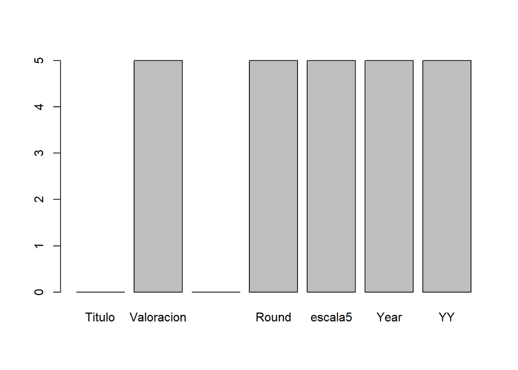

```r
barplot(colSums(is.na(filmin)))
```

El resultado es el número de NA en cada una de las columnas

```r
summarise(filmin, media = mean(Valoracion))
```

```
## # A tibble: 1 × 1
##   media
##   <dbl>
## 1    NA
```

Muchas funciones estadísticas de R tienen un argumento `na.rm` que puede ser establecido en TRUE para omitir valores NA en los cálculos. Con ello conseguimos que al calcular una media (por ejemplo), el resultado sea distinto de NA en caso de que tengamos algún NA.

```r
summarise(filmin, media = mean(Valoracion, na.rm = T))
```

```
## # A tibble: 1 × 1
##   media
##   <dbl>
## 1   7.3
```

## 1.5 Referencias

1. Biblioteca `dplyr` : https://es.r4ds.hadley.nz/05-transform.html#introducci%C3%B3n
2. Pipes https://es.r4ds.hadley.nz/18-pipes.html
3. Ejemplos. Utiliza la función `vignette()` para ver ejemplos de uso de `dplyr` (`vignette("dplyr")`).
4. Para aggregados móviles: biblioteca `RcppRoll`